# Projeto 3: Estudo de caso BlueSky

Marjorie Hoegen

A companhia aérea BlueSky opera uma rota que transporta 146 passageiros e vende as passagens aéreas de acordo com a data de compra:

- Tarifa para compras antecipadas (com pelo menos 14 dias de antecedência) custa U$ 114
- Tarifa cheia custa U$ 174

Como a demanda por passagens antecipadas costuma ser maior, a empresa precisa definir limites de reserva de forma a maximizar a receita. Neste estudo de caso, busca-se definir o nível ideal de proteção de assentos de tarifa cheia e o limite de reserva ideal para cada dia da semana de 19 a 25 de março de 2007. Os dados de base são dados da demanda diária por tarifa cheia nos 12 meses anteriores.

```r
dados <- read_excel("BlueSky_Single-Leg_demand.xls",
                    range = "A6:B371", col_types = c("date","numeric"))
```

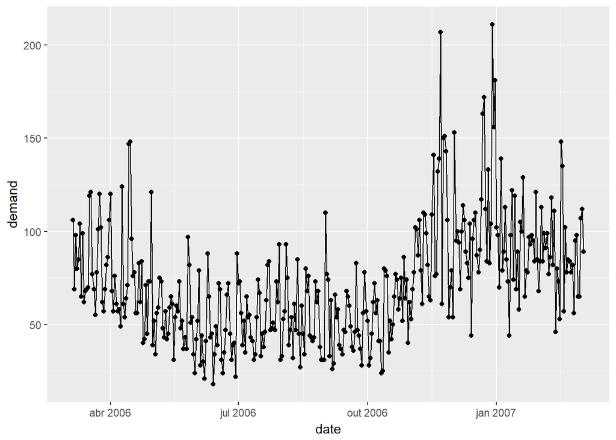

Com os valores dos dois tipos de tarifas é possível determinar um valor crítico:

```r
tarifa.full <- 174
tarifa.low <- 114

valor.critico <- (tarifa.full-tarifa.low)/tarifa.full
```

### Modelo 1: Normal

Este primeiro modelo considera que os dados seguem uma distribuição normal e não faz discriminação do dia da semana.

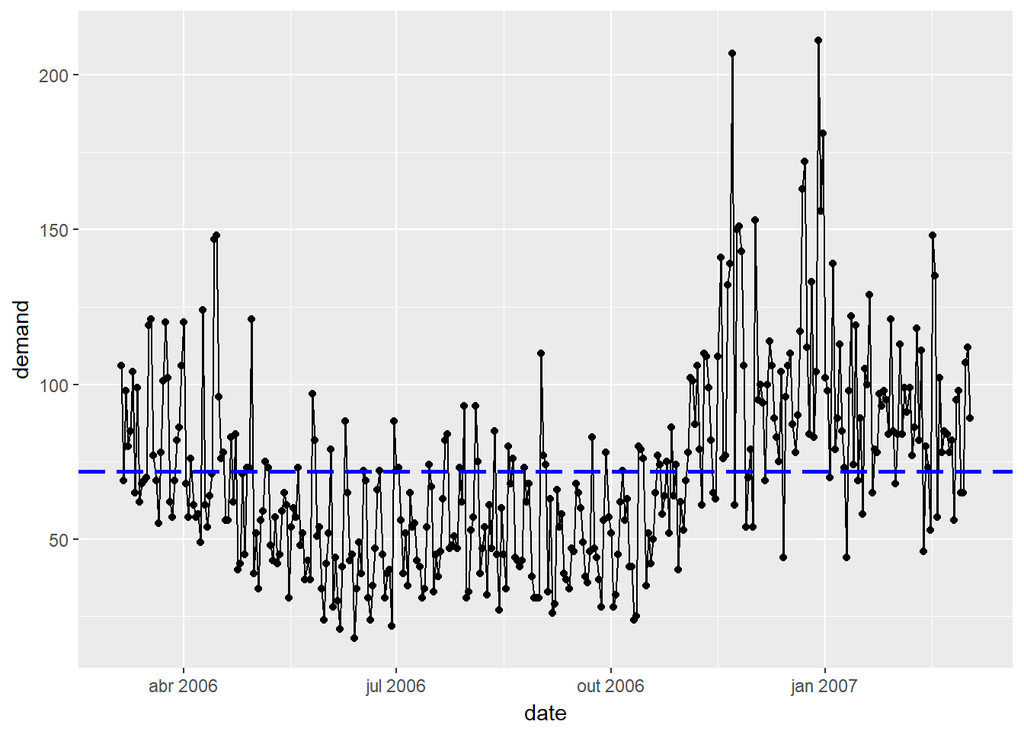

```r
media_1 <- mean(dados$demand)
m_int <-round(media_1,0)
g <- g + geom_hline(yintercept =  media_1, color="blue",
               linetype = "longdash", size = 1)
g
```

Podemos definir o RMSE (Root Mean Square Error) desse modelo e o nível de proteção das tarifas.

```r
rmse_1 <- sd(dados$demand)
rmse_1
```

```
## [1] 31.45953
```

```r
protection_Level_1 <- qnorm(p=valor.critico,mean = media_1, sd = rmse_1 )
protection_Level_1 <- round(protection_Level_1,0)
protection_Level_1
```

```
## [1] 59
```

### Modelo 2: Empírico

Considerando que os dados seguem uma distribuição empírica, podemos usar a função quantile() que retorna os quantis para dadas probabilidades. E de maneira semelhante ao modelo 1, obtemos o nível de proteção e RMSE.

```r
q.model2 <- quantile(dados$demand, c(valor.critico,0.5))
q.model2
```

```
## 34.48276%       50%
##        56        68
```

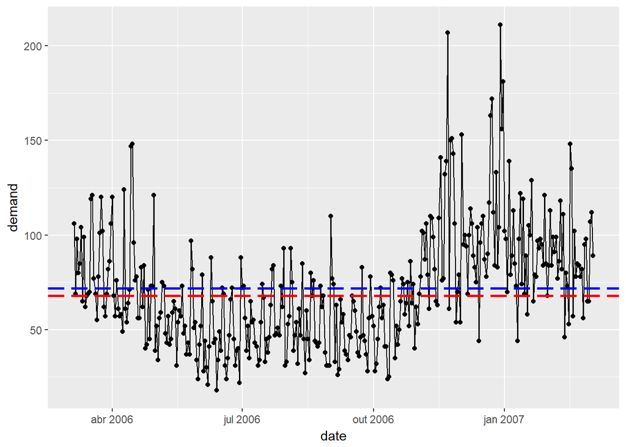

```r
protection_Level_2 <-  q.model2[[1]]
mediana_2 <-  q.model2[[2]]
rmse_2 <- sqrt(mean((dados$demand - mediana_2)^2))
g <- g + geom_hline(yintercept =  mediana_2, color="red",
               linetype = "longdash", size = 1)
g
```

### Modelo 3: Normal com dias da semana

Para um terceiro modelo, podemos considerar uma distribuição normal porém diferenciando os dias da semana.

```r
dados$day <- weekdays(dados$date)
mean.days.normal <- dados %>%
  group_by(day) %>%
  summarise(media.N = mean(demand),
            sd.N= sd(demand),
            prot.Level.3 = qnorm(p=valor.critico,mean = media.N, sd = sd.N))
mean.days.normal <- dados %>%
  group_by(day) %>%
  mutate(media.N = mean(demand),
            sd.N= sd(demand),
            prot.Level.3 = round(qnorm(p=valor.critico,mean = media.N, sd = sd.N),0)
  )
rmse_3 <- sqrt(mean((mean.days.normal$demand - mean.days.normal$media.N)^2))
```

### Modelo 4: Empírico com dias da semana

Podemos fazer o mesmo para a distribuição empírica.

```r
median.days.empirica <- dados %>%
  group_by(day) %>%
  mutate(mediana = median(demand),
         prot.Level.4 = as.integer(quantile(demand,valor.critico))
  )
rmse_4 <- sqrt(mean((median.days.empirica$demand - median.days.empirica$mediana)^2))
```

### Modelo 5: Regressão

Com base nos dados da demanda também podemos fazer uma regressão considerando o mês e os dias da semana.

```r
dados$month <- months(dados$date)

dados$day <- factor(dados$day)
dados$month <- factor(dados$month)

summary(dados$day)
```

```
##       domingo  quarta-feira  quinta-feira        sábado segunda-feira
##            53            52            52            52            52
##   sexta-feira   terça-feira
##            52            52
```

```r
is.factor(dados$day)
```

```
## [1] TRUE
```

```r
levels(dados$day)
```

```
## [1] "domingo"       "quarta-feira"  "quinta-feira"  "sábado"
## [5] "segunda-feira" "sexta-feira"   "terça-feira"
```

```r
#Regressão
dados.fit <- lm(data=dados, demand ~ day + month)
summary(dados.fit)
```

```
##
## Call:
## lm(formula = demand ~ day + month, data = dados)
##
## Residuals:
##     Min      1Q  Median      3Q     Max
## -71.190 -11.812  -0.488  10.789 121.136
##
## Coefficients:
##                  Estimate Std. Error t value Pr(>|t|)
## (Intercept)        82.743      4.515  18.325  < 2e-16 ***
## dayquarta-feira   -21.365      3.999  -5.343 1.66e-07 ***
## dayquinta-feira   -16.872      3.998  -4.220 3.12e-05 ***
## daysábado           8.363      3.995   2.093 0.037061 *
## daysegunda-feira  -17.733      3.996  -4.437 1.23e-05 ***
## daysexta-feira     10.220      3.997   2.557 0.010980 *
## dayterça-feira    -17.525      3.998  -4.384 1.55e-05 ***
## monthagosto       -21.730      5.244  -4.144 4.30e-05 ***
## monthdezembro      32.227      5.241   6.150 2.14e-09 ***
## monthfevereiro     12.923      5.377   2.403 0.016772 *
## monthjaneiro       17.072      5.244   3.256 0.001243 **
## monthjulho        -20.904      5.241  -3.989 8.10e-05 ***
## monthjunho        -28.566      5.286  -5.404 1.21e-07 ***
## monthmaio         -20.863      5.244  -3.979 8.44e-05 ***
## monthmarço         10.106      5.242   1.928 0.054703 .
## monthnovembro      24.487      5.286   4.632 5.12e-06 ***
## monthoutubro      -18.197      5.242  -3.471 0.000583 ***
## monthsetembro     -23.207      5.284  -4.392 1.50e-05 ***
## ---
## Signif. codes:  0 '***' 0.001 '**' 0.01 '*' 0.05 '.' 0.1 ' ' 1
##
## Residual standard error: 20.46 on 347 degrees of freedom
## Multiple R-squared:  0.5968, Adjusted R-squared:  0.5771
## F-statistic: 30.21 on 17 and 347 DF,  p-value: < 2.2e-16
```

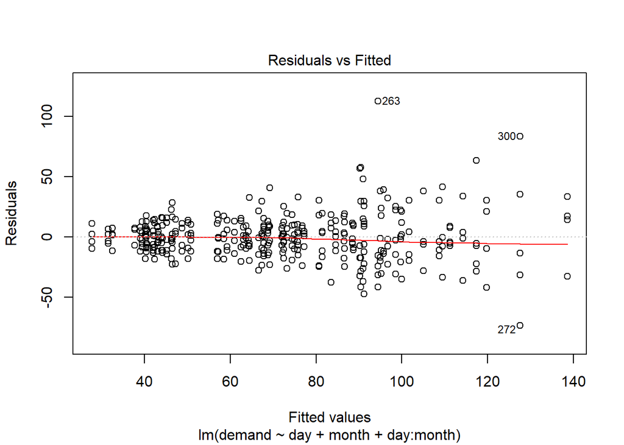

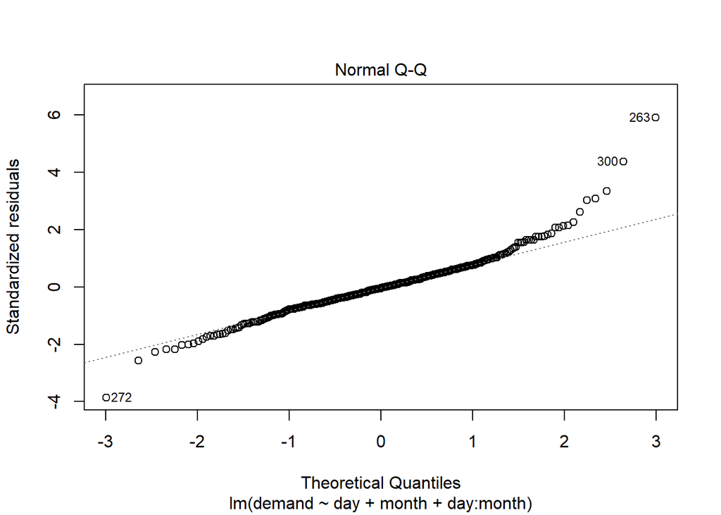

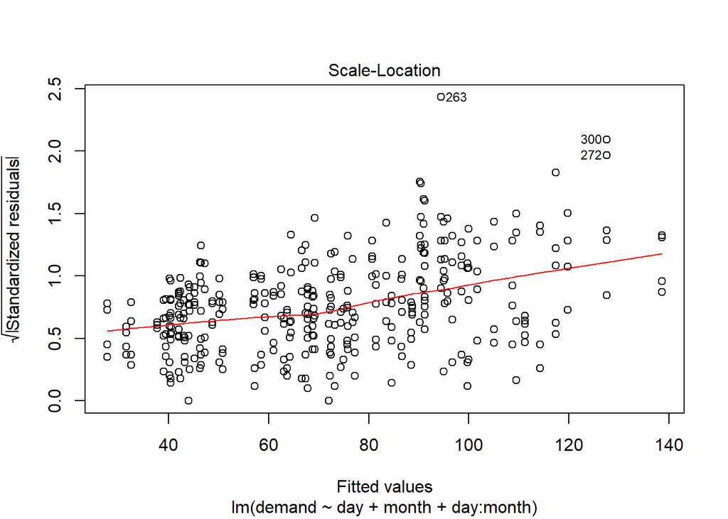

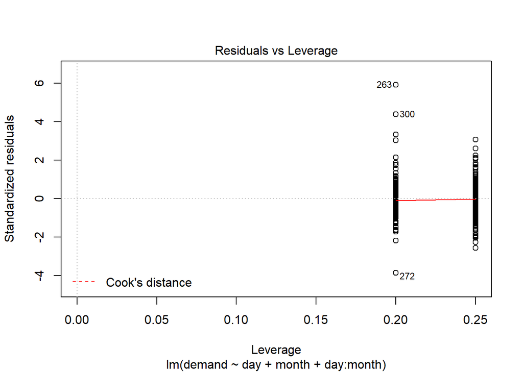

```r
# Incluindo um termo de interação dia-mês
dados.fit <- lm(data=dados, demand ~ day + month + day:month)
plot(dados.fit)
```

Plotando os valores previstos:

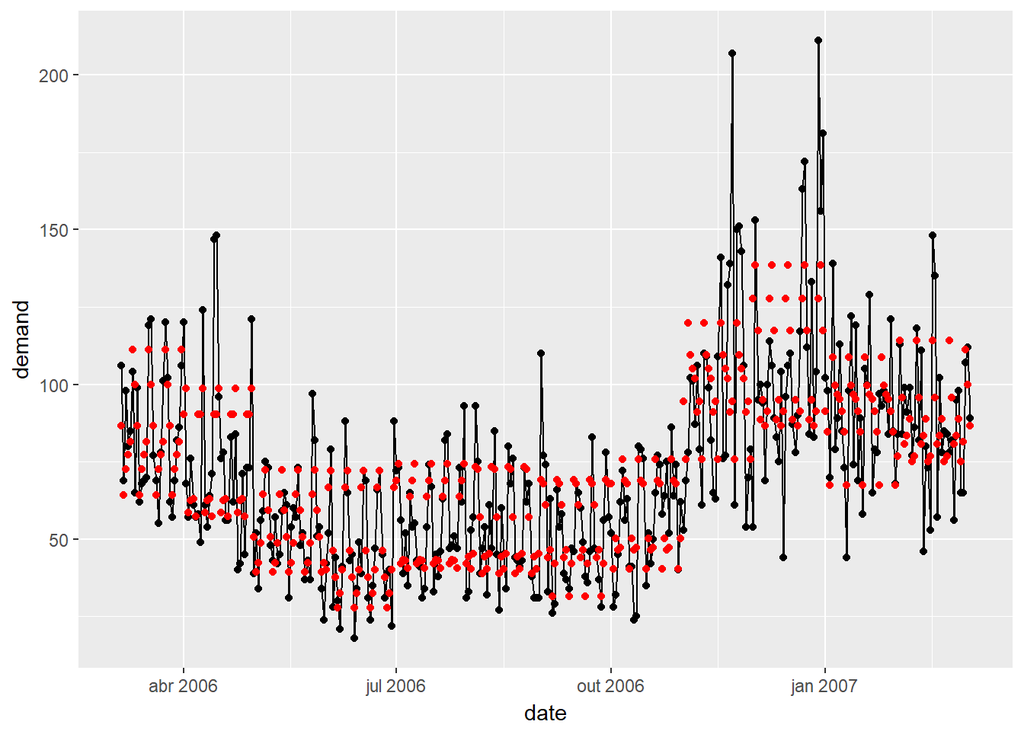

```r
prediction <- predict(dados.fit,newdata = dados )

g <- ggplot(dados, aes(x=date,y=demand)) +
  geom_point() +
  geom_line()

#use fitted values or prediction
g + geom_point(aes(x=dados$date,y=dados.fit$fitted.values),
               color = "red")
```

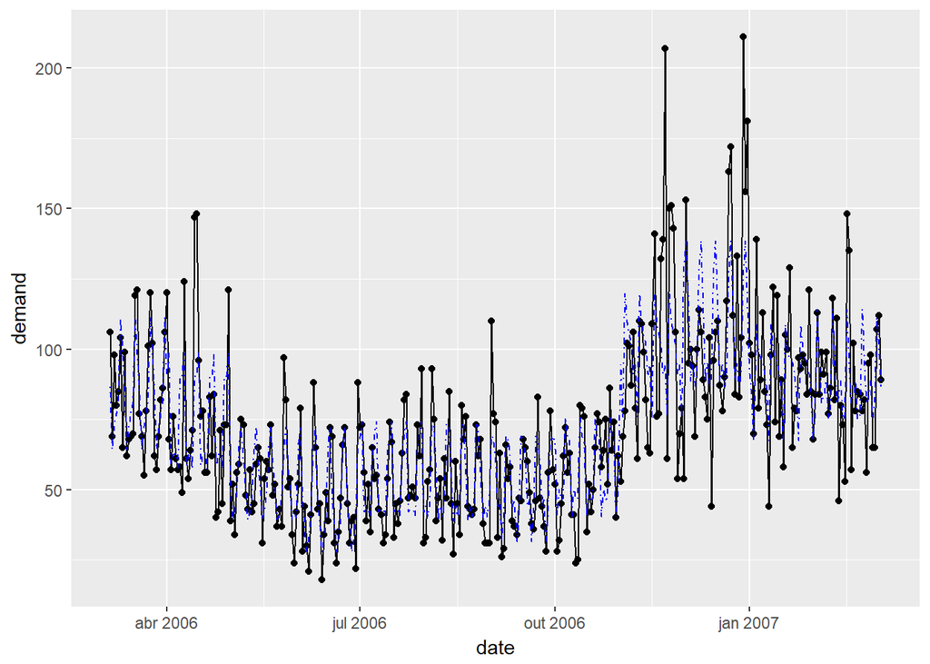

```r
g + geom_line(aes(x=dados$date,y=prediction),
              linetype="dotdash",
              color = "blue")
```

### Modelo 6: Regressão melhorada

Para uma regressão melhor, podemos incluir alguns feriados.